# Praca Domowa 5

Agata Makarewicz

13 05 2021

### Wstęp

Naszym zadaniem będzie analiza wyjaśniająca decyzję modelu uczenia maszynowego (w jaki sposób poszczególne zmienne na nią wpływają). Będą to wyjaśnienia globalne, dla danego modelu, a nie pojedynczych predykcji.

Skorzystamy ze zbioru danych `phones` zawierającego informacje o cechach różnych telefonów dostępnych na rynku. Rozważamy problem regresji (chcemy przewidzieć zmienną `price`) przy wykorzystaniu lasu losowego zaimplementowanego w pakiecie `ranger` (a także innych modeli).

|  | name | brand | back_camera_mpix | front_camera_mpix | battery_mAh | ram_gb | flash_gb | diag | height_px | width_px | price |
| --- | --- | --- | --- | --- | --- | --- | --- | --- | --- | --- | --- |
| 1 | Xiaomi Mi 10T 6+128GB | Xiaomi | 64 | 20 | 5000 | 6 | 128 | 6.67 | 2400 | 1080 | 1999 |
| 2 | Samsung Galaxy M21 | Samsung | 48 | 20 | 6000 | 4 | 64 | 6.40 | 2340 | 1080 | 899 |
| 3 | Samsung Galaxy Note20 | Samsung | 64 | 10 | 4300 | 8 | 256 | 6.70 | 2400 | 1080 | 3749 |

Zbiór posiada ok. 11% obserwacji z brakującymi wartościami w niektórych kolumnach (`back_camera_mpix`,`front_camera_mpix`), które na potrzeby tego zadania (tworzenia modelu) zostaną uzupełnione zerami (gdyż brak aparatu oznacza w praktyce 0 Mpix). Pominiemy również zmienną `name`, która jest w oczywisty sposób skorelowana ze zmienną `brand` oraz praktycznie unikalna dla każdej obserwacji (328/414 wartości unikalnych po usunięciu braków), oraz zmienne `width_px` i `height_px`, które są silnie ze sobą skorelowane i wyjaśniane przez zmienną `diag`.

```r
model <- ranger(price~., data = data, num.trees = 50)
explainer <- DALEX::explain(model = model, data = data[,-11], y = data$price)
```

### Partial Dependence Profile (PDP) dla wybranych zmiennych

Na podstawie poprzedniej pracy domowej wybrane zostały jedne z najważniejszych zmiennych:

- ram_gb
- flash_gb
- brand
- front_camera_mpix

```
## 'variable_type' changed to 'categorical' due to lack of numerical variables.
```

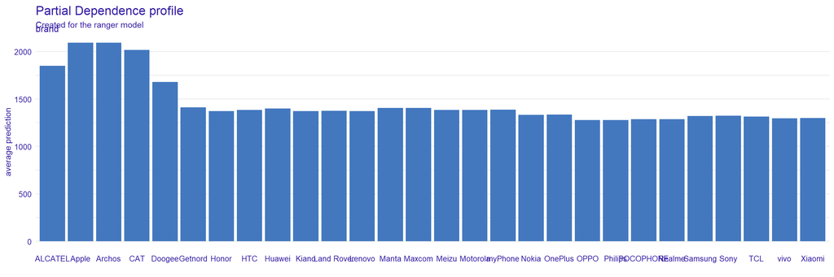

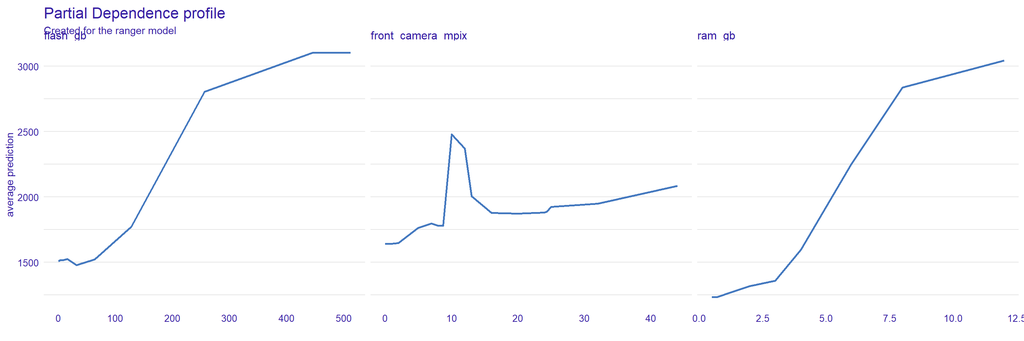

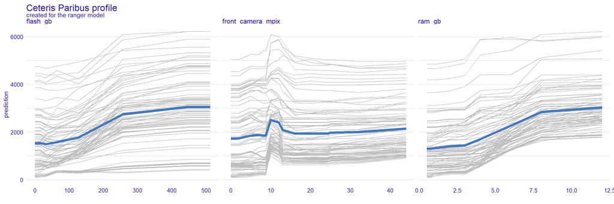

Dla zmiennych `flash_gb` oraz `ram_gb` możemy zaobserwować podobne profile - wraz ze wzrostem wartości zmiennej zwiększa się przewidywana cena telefonu. Różnica polega na tym, że dla zmiennej `ram_gb` przyrosty są w miarę stabilne, i średnio większe niż dla `flash_gb`, ale dla `flash_gb` mamy większe zróżnicowanie - czasem przyrosty są minimalne, czasem bardzo duże. Oba te trendy pokrywają się z wcześniejszymi analizami, które wykazały spory pozytywny wpływ tych zmiennych na cenę telefonu. Jeśli chodzi o zmienną `front_camera_mpix`, możemy zauważyć wyraźny skok wartości predykcji w okolicach 10 Mpix, a następnie spadek do prawie początkowej wartości, po którym następuje stały, niewielki wzrost predykcji (średnio) , lub też jej stabilizacja (w niektórych przypadkach). To charakterystyczne zachowanie obserwowaliśmy już również w poprzednich analizach, dla pojedynczych predykcji. W przypadku zmiennej `brand` możemy zauważyć, że dla większości marek obserwujemy bardzo zbliżoną wartość predykcji; odznacza się jedynie 5 marek, m.in. Apple, dla której w lokalnych wyjaśnieniach faktycznie oberwowaliśmy “niespodziewane” wysokie ceny telefonów nieproporcjonalne do posiadanych parametrów.

### Accumulated Local Effect (ALE) dla wybranych zmiennych

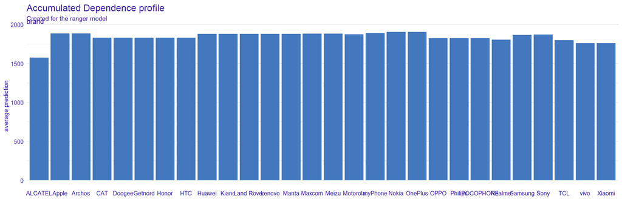

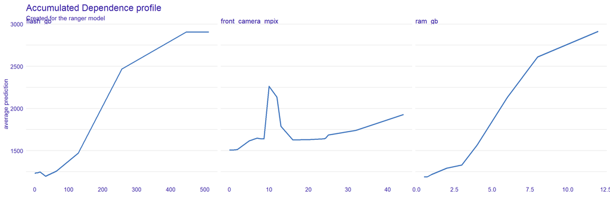

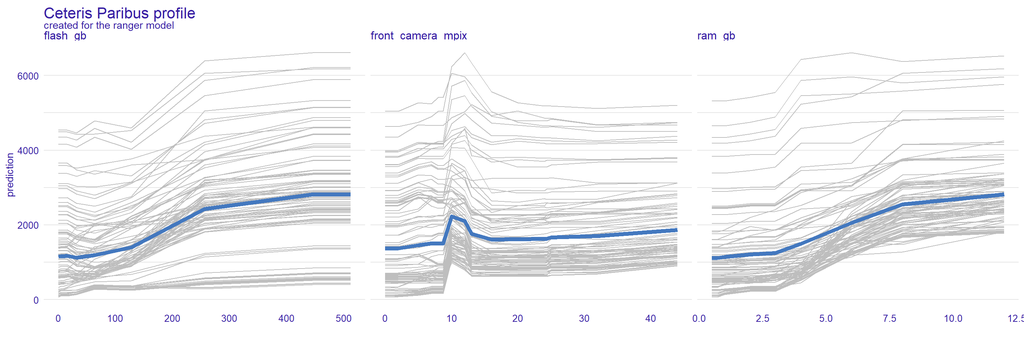

W przypadku ALE nie obserwujemy praktycznie żadnych zmian w profilach powyższych 3 zmiennych. Wyjątek stanowi zmienna `brand`, dla której obserwujemy wyrównanie średniej wartości predykcji dla wszystkich marek z wyjątkiem Alcatel.

### Zmiana rozkładu siatki i ustawienia punktów

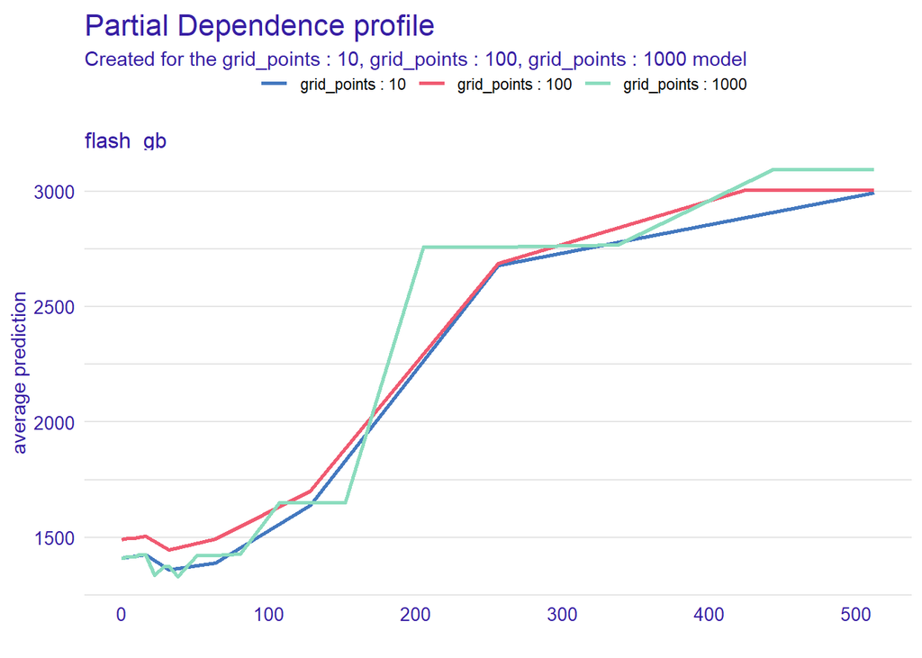

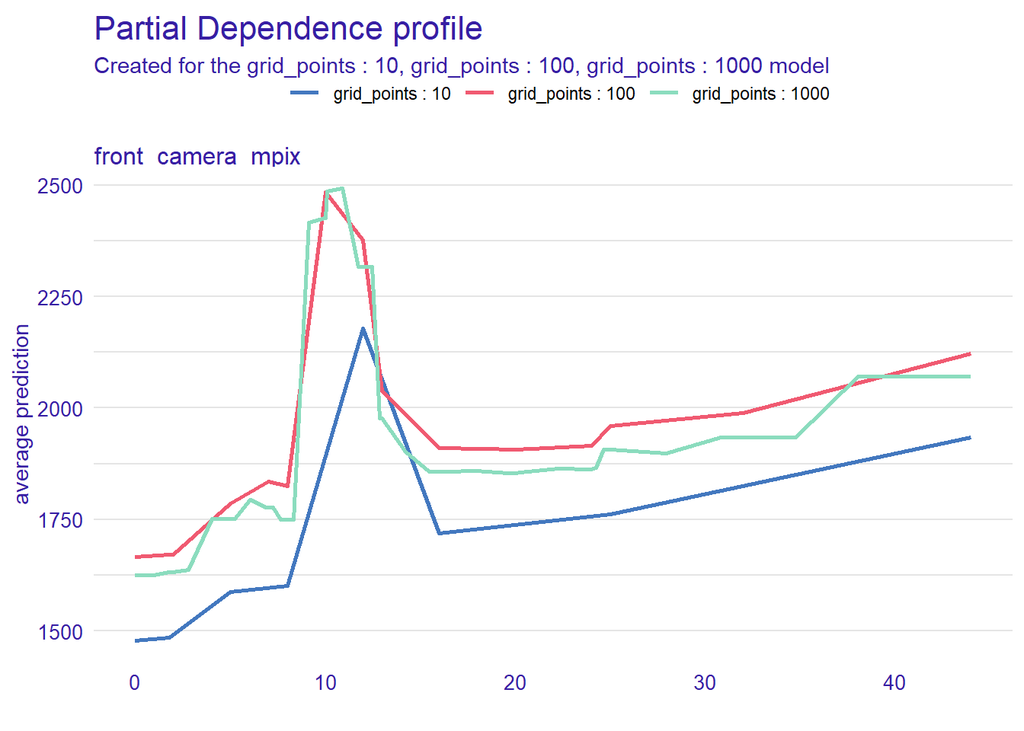

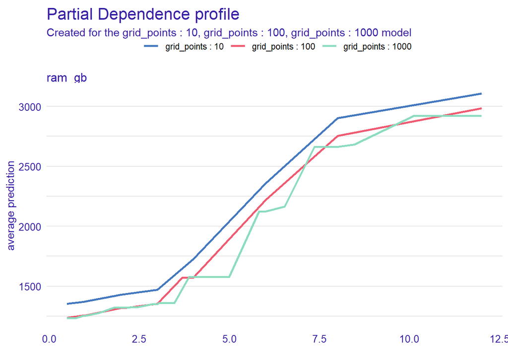

Manipulując rozmiarem siatki możemy zauważyć, że dla zmiennych `flash_gb` oraz `ram_gb` dla rozmiaru 10 oraz 100 nie obserwujemy praktycznie żadnej różnicy; natomiast dla 1000 profil zmienia się i bardziej szczegółowiej przedstawia poszczególne przyrosty wartości predykcji, a także pozwala lepiej odróżnić profile dla obu zmiennych. W przypadku zmiennej `front_camera_mpix` możemu zauważyć, że siatka o rozmiarze 10 wyłapuje co prawda charakterystyczny skok w okolicy 10 Mpix, ale odrobinę przesunięty od właściwej wartości (10). Co ciekawe, zmiana rozmiaru siatki powoduje wzrost wartości predykcji.

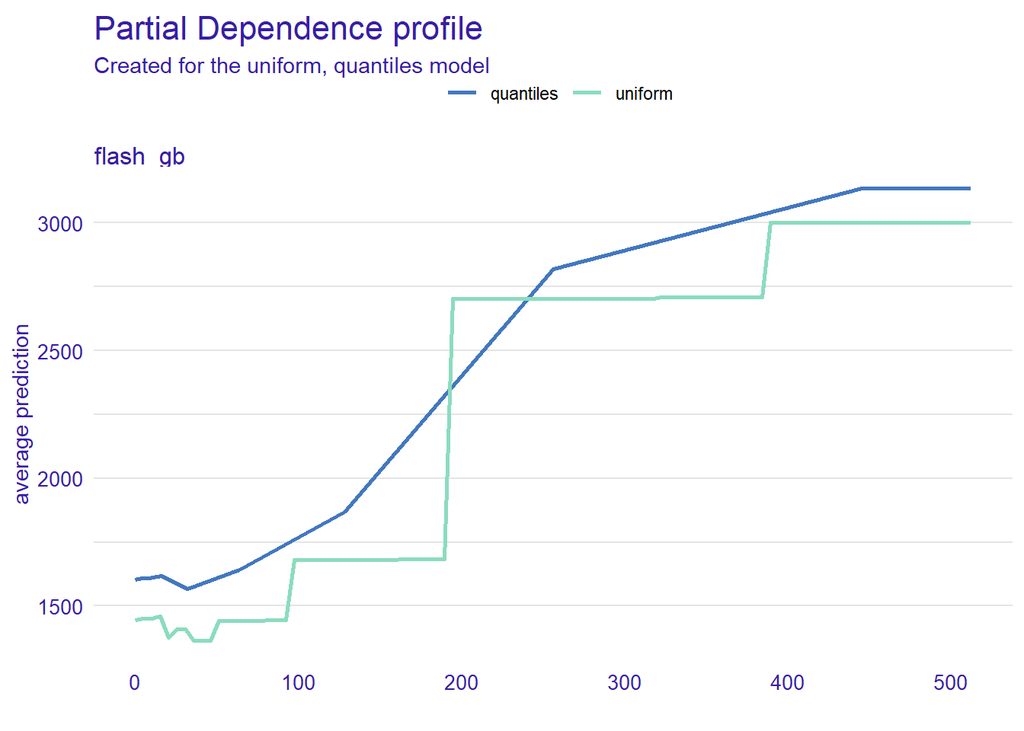

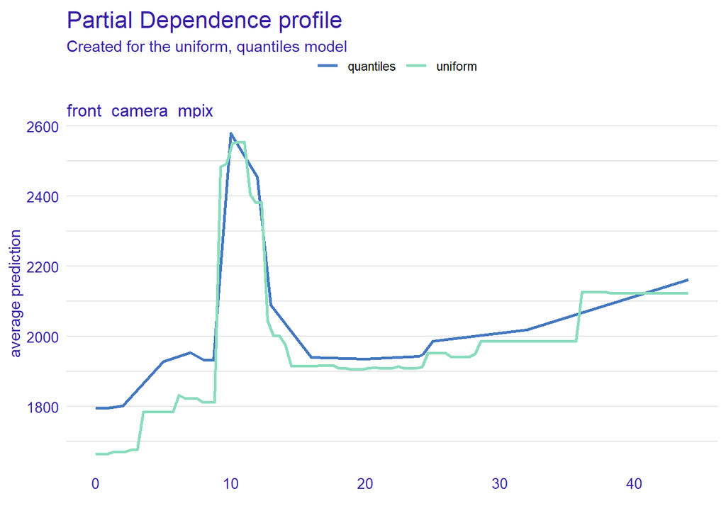

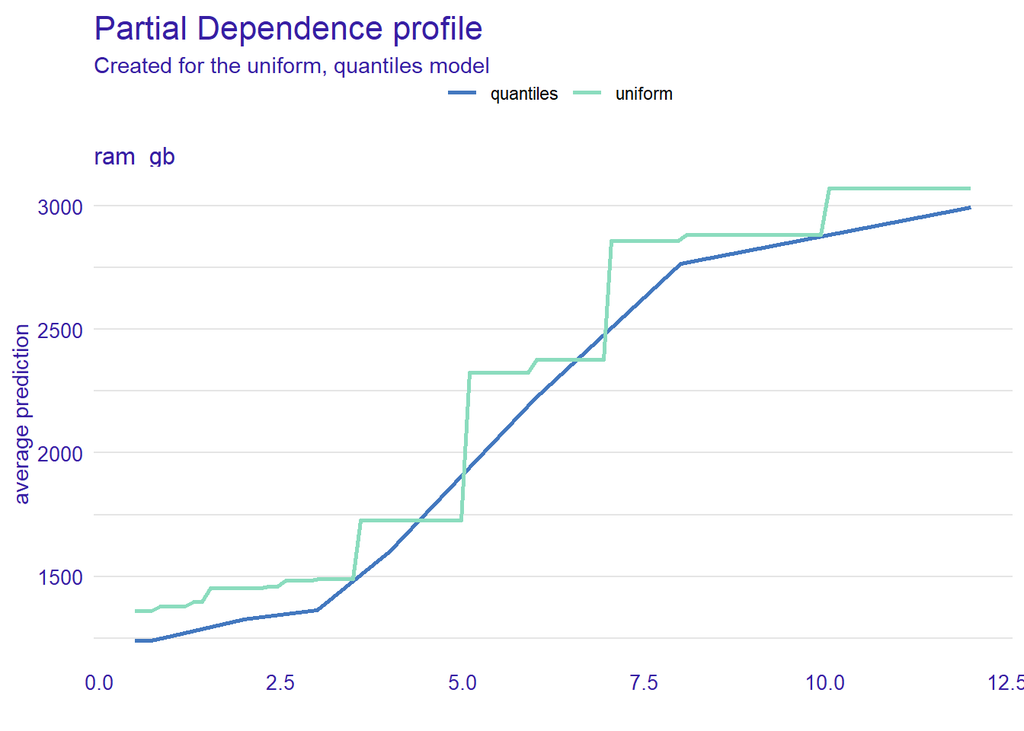

Zmieniając rozkład z kwantylowego na jednostajny możemy zaobserwować znaczną zmianę w wyglądzie prostych dla zmiennych `flash_gb` oraz `ram_gb` - zamiast praktycznie gładkiego profilu obserwujemy “schodkową” łamaną. Dla zmiennej `front_camera_mpix` nie obserwujemy znacznych różnic w samym profilu, jest on jedynie nieco bardziej szczegółowy dla rozkładu jednostajnego.

### Porównanie PDP i ALE dla wybranej zmiennej

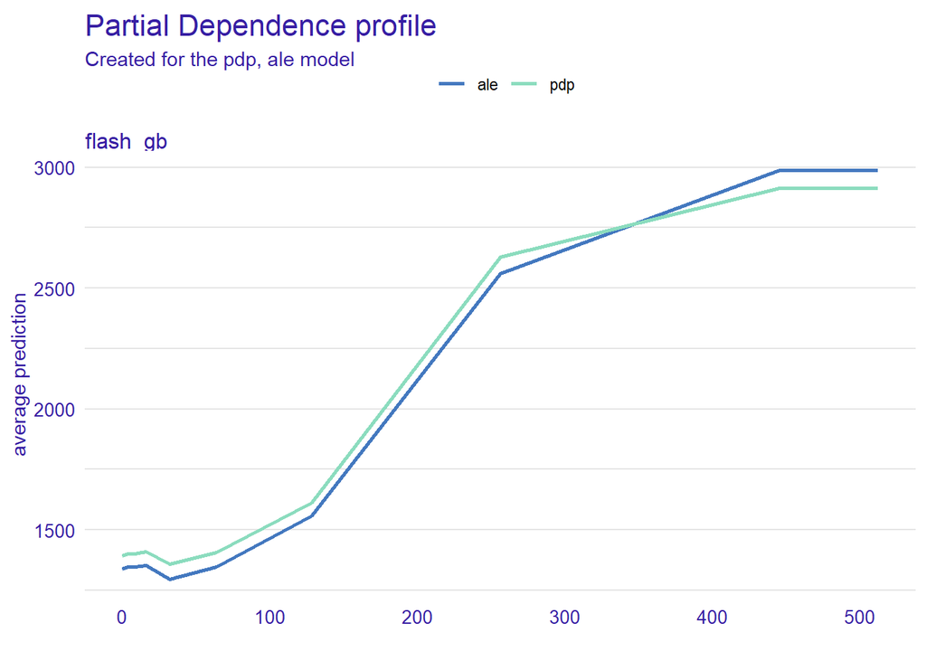

Tak jak zaobserwowaliśmy wcześniej, profil zmiennej praktycznie nie zmienia się, ale wartości predykcji są minimalnie większe w przypadku profilu PDP, co jest efektem tego, że w obu przypadkach rozważamy różne rozkłady (graniczny bądź warunkowy).

$~$